# Welcome to Todos Santos!

Thank you for joining us for our computational biology and genomics workshop. Here is a summary of the topics that we are looking forward to covering over the course of the week.

### Monday: Introduction to high-throughput sequencing and computational biology

- **08:00-08:45** Breakfast
- **09:00-10:30** Introduction to Todos Santos and Group Discussion **[Slides]**
- **10:30-11:00** High-Throughput Sequencing Technologies [**[Slides]**](https://github.com/stenglein-lab/2019_Todos_Santos/blob/master/lectures/Stenglein_introduction_to_genomics_and_sequencing_lecture.pdf)
- **11:00-12:00** UNIX and Command Line Tools
- **12:00-13:00** Lunch
- **13:00-16:00** [Manipulating and Obtaining Genomics Data](https://github.com/stenglein-lab/2019_Todos_Santos/blob/master/exercises/mapping_assembly_exercise.md) [**[Slides]**](https://github.com/stenglein-lab/2019_Todos_Santos/blob/master/lectures/Stenglein_databases_lecture.pdf)
- **16:00-17:30** Alignment and Read Mapping

### Tuesday: RNA-seq

- **08:00-08:45** Breakfast
- **09:00-12:00** RNA-seq Data Analysis I **[Slides]**
- **12:00-13:00** Lunch
- **13:00-17:00** RNA-seq Data Analysis II
- **17:00-18:30** Research Presentations (with Refreshments)

### Wednesday: Comparative genomic analysis

- **07:00-07:45** Breakfast
- **08:00-14:00** Local Excursion to Cacti Sanctuary and El Triunfo
- **14:00-15:30** [Assembly and Annotation](https://github.com/stenglein-lab/2019_Todos_Santos/blob/master/exercises/mapping_assembly_exercise.md) [**[Slides]**](https://github.com/stenglein-lab/2019_Todos_Santos/blob/master/lectures/Stenglein_de_novo_assembly_lecture.pdf)
- **15:30-17:00** [Variant Calling](https://github.com/stenglein-lab/2019_Todos_Santos/blob/master/exercises/variant_exercise.md) [**[Slides]**](https://github.com/stenglein-lab/2019_Todos_Santos/blob/master/lectures/Stenglein_intrahost_variants.pdf)

### Thursday: Comparative genomic analysis (cont.) and Data Visualization

- **08:00-08:45** Breakfast
- **09:00-10:30** Local BLAST and Comparative Genomics **[Slides]**
- **10:30-11:00** Discussion on Experimental Design
- **11:00-12:00** Metagenomics and Microbial Diversity [**[Slides]**](https://github.com/stenglein-lab/2019_Todos_Santos/blob/master/lectures/Stenglein_metagenomics_lecture.pdf)
- **12:00-13:00** Lunch
- **13:00-14:30** Introduction to R, R Markdown, and Data Visualization **[Slides]**
- **14:30-15:15** Plotting Genomic Data with R and ggplot
- **15:15-16:00** Figure Drawing in R
- **16:00-17:00** Circular Representations of Genomic Data with Circos
- **17:00-20:00** Workshop Dinner

### Friday: Scripting and GitHub

- **08:00-08:45** Breakfast
- **09:00-10:00** Code Management (GitHub)
- **10:00-12:00** Bash Scripting **[Slides]**
- **12:00-13:00** Lunch
- **13:00-17:00** Python Scripting **[Slides]**

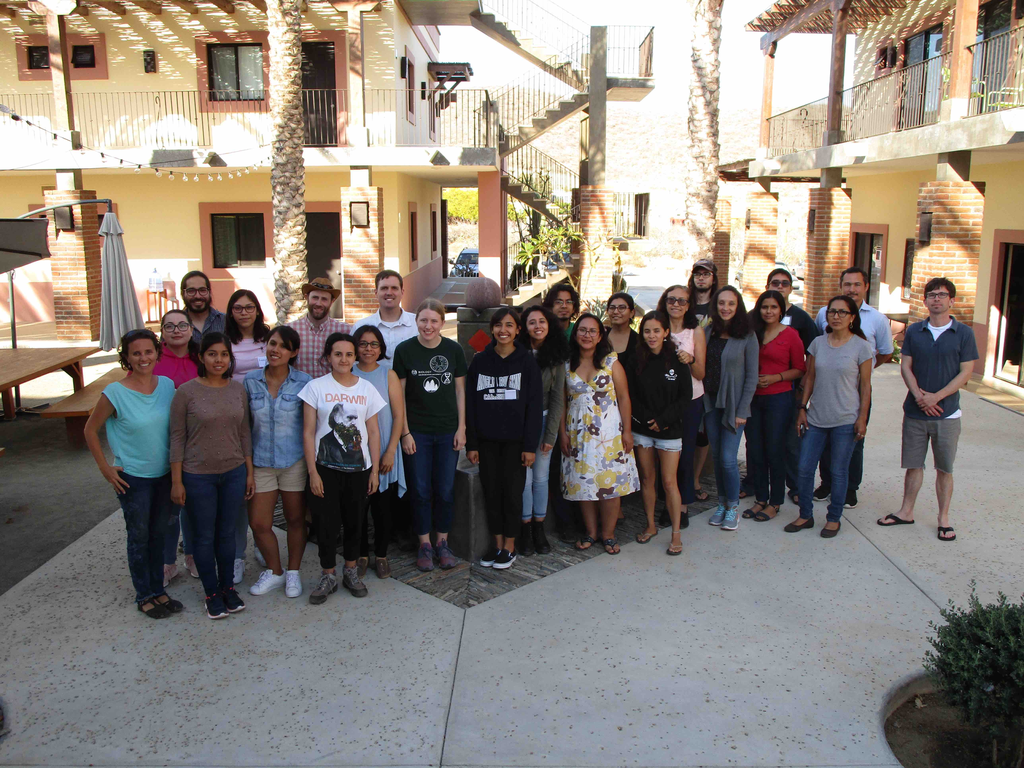

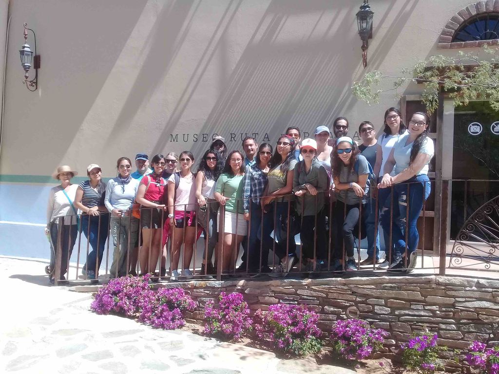

[figure not shown]

Supported by the Society of Molecular Biology and Evolution, Colorado State University, and the National Science Foundation